# Intro to Water Quality

January 21, 2020

## Introduction (Week 1)

Goals for today

- Pique your interest
- Get to know each other

## Land-Use change

- What kind of land-use change can you see in the video below?
- What human impacts are not captured by this video or by satellite observation in general?
- Which land-use changes are most likely to impact inland waters?

[video not shown]

If you enjoy looking at these timelapses, I encourage you to play around with this [website from Google and Carnegie Melon](https://earthengine.google.com/timelapse/) which shows the entire globe changing over the past 30 years.

## My work on land-use change - Mining in West Virginia

[figure not shown]

[video not shown]

## Types of Water Quality Change

- What water quality problem do you think is most pressing right now in Colorado? in the United States? the Globe?
- What causes the water quality problem you identifed from above? Was it land-use change or something else?

## Examples of water quality impacts

For each image answer the following questions

- what is the water quality impact you see?
- What may have caused this impact?
- Is it natural or human-caused?

## Lake Erie

[figure not shown]

## Lake Erie 2

[figure not shown]

## Animas

[figure not shown]

## West Virginia

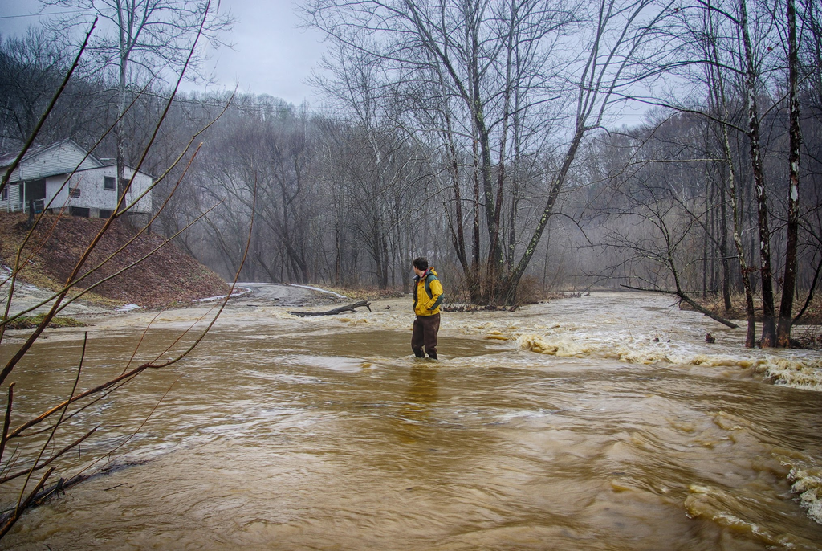

## West Virginia 2

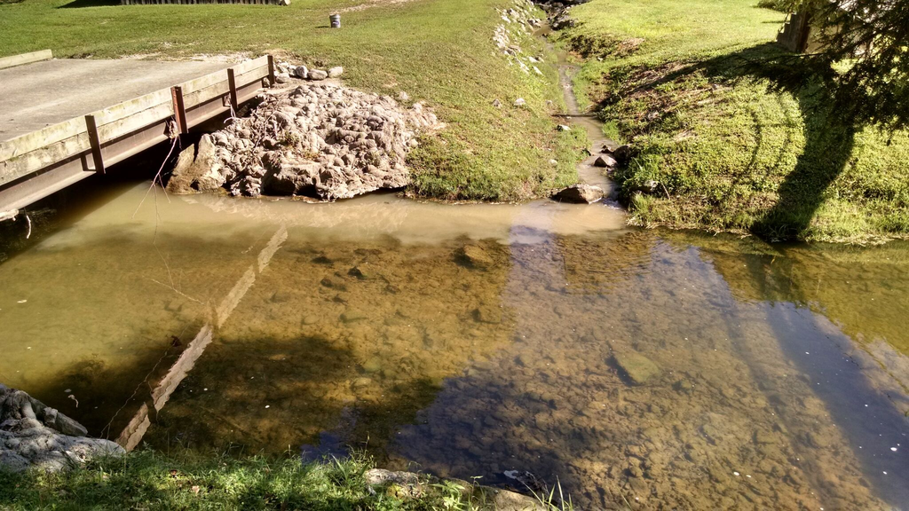

## Gulf Coast

[figure not shown]

## Fort Collins

[interactive chart not shown]

## Boulder

[figure not shown]

and on and on and on.

## Treatment

- Most water quality problems are pernicious and wicked
- Difficult to treat once they start and hard to disentangle from the land-use change that causes them
- What are some ways we (globally) are improving water quality?

## Summary

- Which impacts do you think will be fixed in the next year, decade, century?
- The goal of this course is for you to intuitively and quantitatively understand the linkages between human’s actions on land and our downstream water quality impacts.